# [MPDW] Tugas Praktikum 4

### Scatter Plot

#### $Y_t$ dengan $Y_{t-1}$

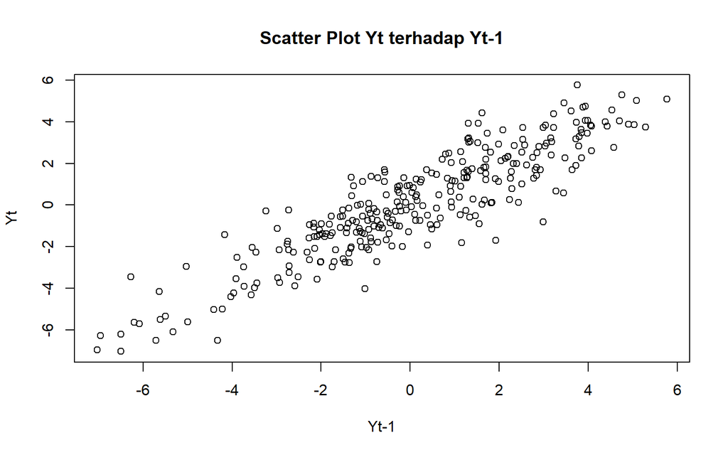

```r
yt_arma <- arma[2:300]
yt_1_arma <- arma[1:299]

plot(yt_1_arma, yt_arma,
     main = "Scatter Plot Yt terhadap Yt-1",
     xlab = "Yt-1",
     ylab = "Yt")
```

```r
cor(yt_arma,yt_1_arma)
```

```
## [1] 0.8955216
```

Berdasarkan scatterplot dan nilai korelasi tersebut, terlihat bahwa terdapat hubungan positif antara Yt dengan Yt−1

#### $Y_t$ dengan $Y_{t-2}$

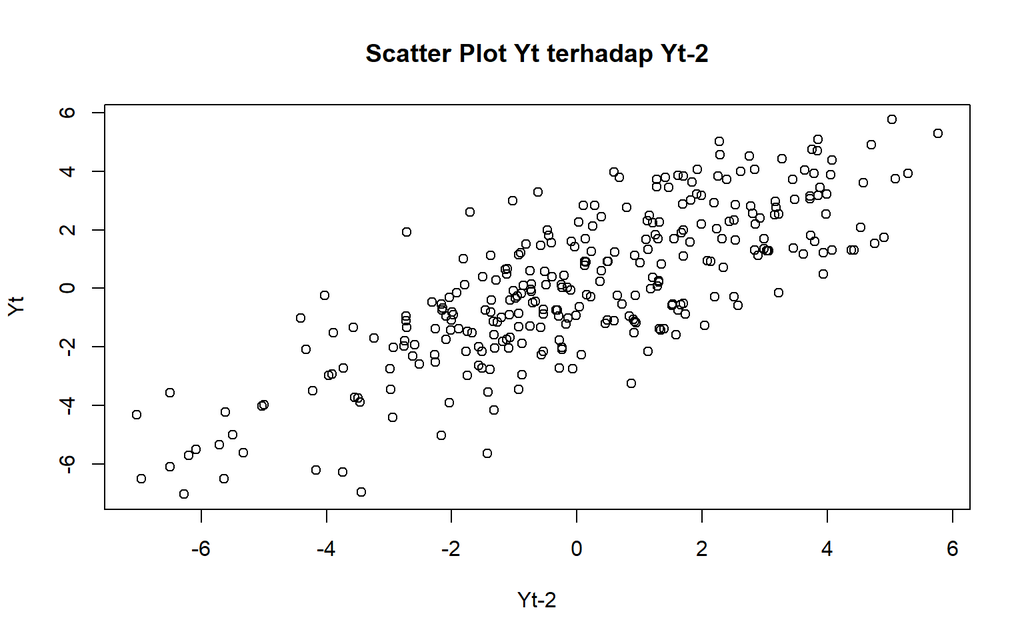

```r
yt_arma_lag2 <- arma[3:300]
yt_2_arma <- arma[1:298]

plot(yt_arma_lag2, yt_2_arma,
     main = "Scatter Plot Yt terhadap Yt-2",
     xlab = "Yt-2",
     ylab = "Yt")
```

```r
cor(yt_arma_lag2,yt_2_arma)
```

```
## [1] 0.7899614
```

Berdasarkan scatterplot dan nilai korelasi tersebut, terlihat bahwa terdapat hubungan positif antara Yt dengan Yt-2 dan lebih lemah dibandingkan hubungan dengan Yt-1

#### $Y_t$ dengan $Y_{t-3}$

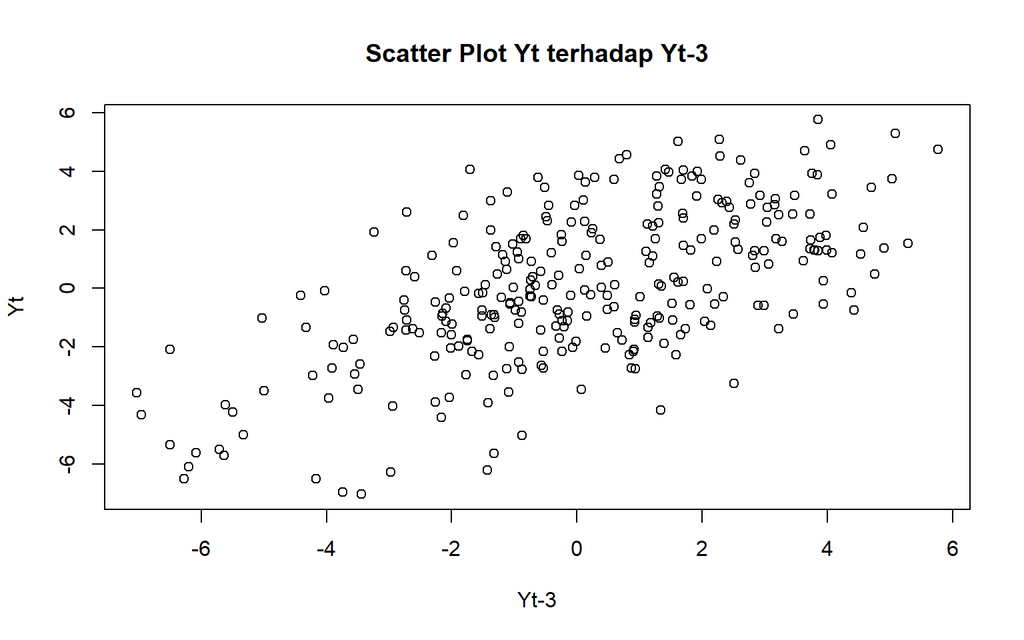

```r
yt_arma_lag3 <- arma[4:300]
yt_3_arma <- arma[1:297]

plot(yt_arma_lag3, yt_3_arma,
     main = "Scatter Plot Yt terhadap Yt-3",
     xlab = "Yt-3",
     ylab = "Yt")
```

```r
cor(yt_arma_lag3,yt_3_arma)
```

```
## [1] 0.6195458
```

Berdasarkan scatterplot dan nilai korelasi tersebut, terlihat bahwa terdapat hubungan positif antara Yt dengan Yt-3 dan lebih lemah dibandingkan hubungan dengan Yt-1 dan Yt-2

### Autokorelasi

#### Autokorelasi Data Bangkitan Manual

```r
rho1_arma_manual <- cor(arma[2:300],arma[1:299])
rho2_arma_manual <- cor(arma[3:300],arma[1:298])
rho3_arma_manual <- cor(arma[4:300],arma[1:297])

rho1_arma_manual
```

```
## [1] 0.8955216
```

```r
rho2_arma_manual
```

```
## [1] 0.7899614
```

```r
rho3_arma_manual
```

```
## [1] 0.6195458
```

#### Autokorelasi Teoritis

```r
psi_arma <- numeric(1000)

psi_arma[1] <- 1

psi_arma[2] <- phi_arma1 + theta_arma1

psi_arma[3] <- phi_arma1 * psi_arma[2] +
               phi_arma2 +
               theta_arma2

for(i in 4:1000){
  psi_arma[i] <- phi_arma1 * psi_arma[i-1] +
                 phi_arma2 * psi_arma[i-2]
}

gamma_arma <- numeric(4)

for(k in 0:3){
  gamma_arma[k+1] <-
    sum(
      psi_arma[1:(1000-k)] *
      psi_arma[(1+k):1000]
    )
}

rho_arma_teori <- gamma_arma / gamma_arma[1]

rho_arma_teori
```

```
## [1] 1.0000000 0.8591993 0.7491908 0.5464353
```

#### Perbandingan

```r
data.frame(
  Lag = 1:3,
  Simulasi = c(
    rho1_arma_manual,
    rho2_arma_manual,
    rho3_arma_manual
  ),
  Teoritis = c(
    rho_arma_teori[2],
    rho_arma_teori[3],
    rho_arma_teori[4]
  ))
```

```
##   Lag  Simulasi  Teoritis
## 1   1 0.8955216 0.8591993
## 2   2 0.7899614 0.7491908
## 3   3 0.6195458 0.5464353
```

Autokorelasi pada proses ARMA(2,2) bernilai positif dan semakin menurun pada lag yang lebih tinggi. Hasil simulasi menunjukkan pola yang sejalan dengan nilai teoritis, meskipun terdapat perbedaan nilai akibat variasi sampel. Hal ini sesuai dengan karakteristik ARMA(2,2), di mana ACF menurun secara bertahap (tails off) dan tidak langsung terputus pada lag tertentu

## Pembangkitan Data dengan arima.sim()

### Pembangkitan Data

```r
set.seed(2026)

n_arma_sim <- 300

arma_sim <- arima.sim(
  list(
    order = c(2,0,2),
    ar = c(0.5, 0.2),
    ma = c(0.4, 0.6)
  ),
  n = n_arma_sim
)

arma_sim
```

```
## Time Series:
## Start = 1
## End = 300
## Frequency = 1
##   [1]  4.14584335  4.49093054  5.09328169  3.99330853  4.00549325  2.29586142
##   [7]  2.27975750  1.76176265  2.77406911  2.90817713  2.05327605  2.18491058
##  [13]  0.37403840 -0.51686279 -0.36346983 -1.87248206 -0.71711035 -2.16655756
##  [19]  0.04200536  0.36653863  0.92477181  1.60112843  1.49024927  0.54566275
##  [25]  0.15261226 -1.52959089 -0.78083965 -1.71975162 -1.23575047 -2.67764652
##  [31] -3.18032947 -3.11794068 -3.71707962 -2.94284596 -2.70352892 -2.15707272
##  [37] -1.88956683 -3.34635104 -3.19230034 -5.21507941 -2.97686759 -4.15363046
##  [43] -2.23366191 -1.97076804 -1.12995541  0.70176205 -0.18007337  0.96311288
##  [49] -0.86246855  1.76105846  1.65924126  2.38823837  2.58640899  0.72332157
##  [55]  2.39672963  0.09775303 -0.58543803 -1.64443875 -1.04630008 -0.55660600
##  [61] -0.74279964  0.38229467  2.47116852  1.02478986  3.14548324  0.71714393
```

[output cut: 39 more lines]

### Plot

#### Plot Time Series

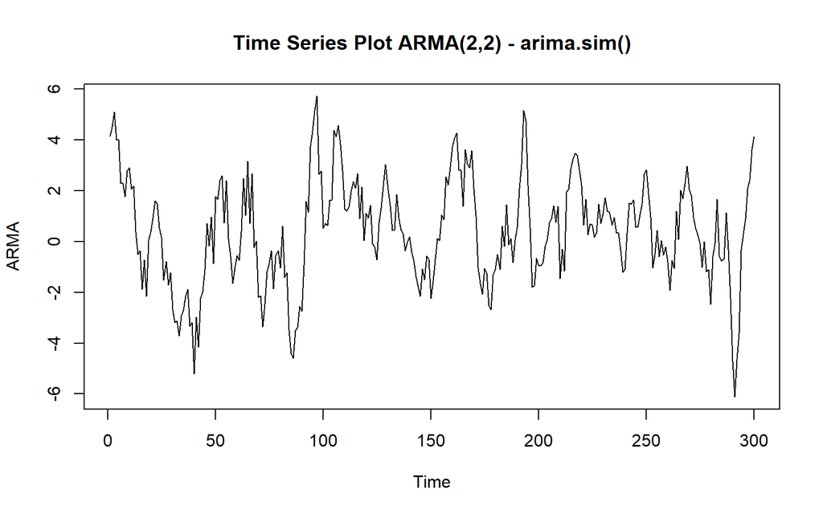

```r
ts.plot(arma_sim,
        main = "Time Series Plot ARMA(2,2) - arima.sim()",
        ylab = "ARMA",
        xlab = "Time")
```

Berdasarkan plot time series, data berfluktuasi di sekitar rata-rata yang relatif konstan dan tidak menunjukkan adanya tren maupun pola musiman yang jelas.

#### Plot ACF

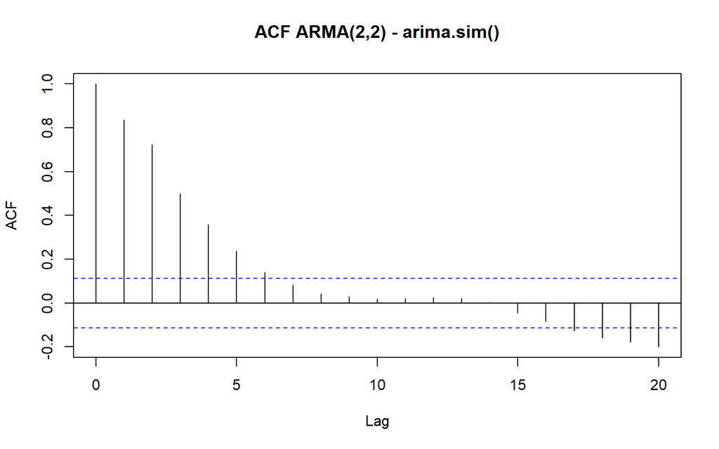

```r
acf(arma_sim,
    lag.max = 20,
    main = "ACF ARMA(2,2) - arima.sim()")
```

ACF menunjukkan pola menurun secara bertahap (tails off) dari lag 1 hingga beberapa lag berikutnya

#### Plot PACF

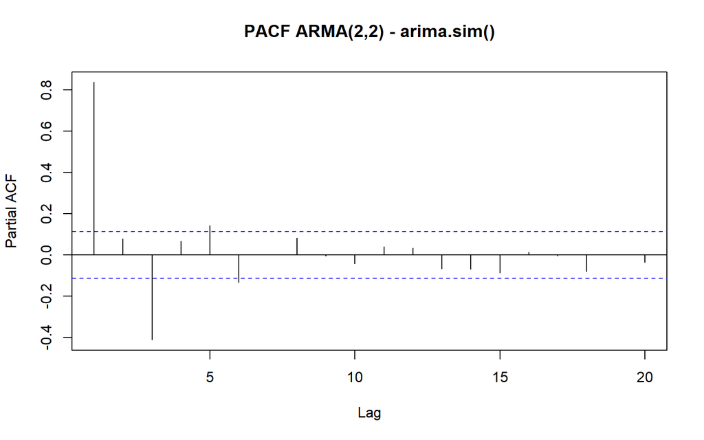

```r
pacf(arma_sim,
     lag.max = 20,
     main = "PACF ARMA(2,2) - arima.sim()")
```

#### Plot EACF

```r
TSA::eacf(arma_sim)
```

```
## AR/MA
##   0 1 2 3 4 5 6 7 8 9 10 11 12 13
## 0 x x x x x x o o o o o  o  o  o
## 1 o x o o o o o o o o o  o  o  o
## 2 x x x o o o o o o o o  o  o  o
## 3 x x x x o o o o o o o  o  o  o
## 4 x x x x o o o o o o o  o  o  o
## 5 x x x x o o o o o o o  o  o  o
## 6 o x o x o o o o o o o  o  o  o
## 7 o x o o o o o o o o o  o  o  o
```

#### Identifikasi Stasioneritas

```r
adf.test(arma_sim)
```

```
##
##  Augmented Dickey-Fuller Test
##
## data:  arma_sim
## Dickey-Fuller = -5.131, Lag order = 6, p-value = 0.01
## alternative hypothesis: stationary
```

$H_0$ : Data tidak stasioner dalam rataan $H_1$ : Data stasioner dalam rataan

Berdasarkan uji ADF tersebut, didapat p-value sebesar 0.01 yang lebih kecil dari taraf nyata 5% sehingga tolak dan menandakan bahwa data stasioner dalam rataan.

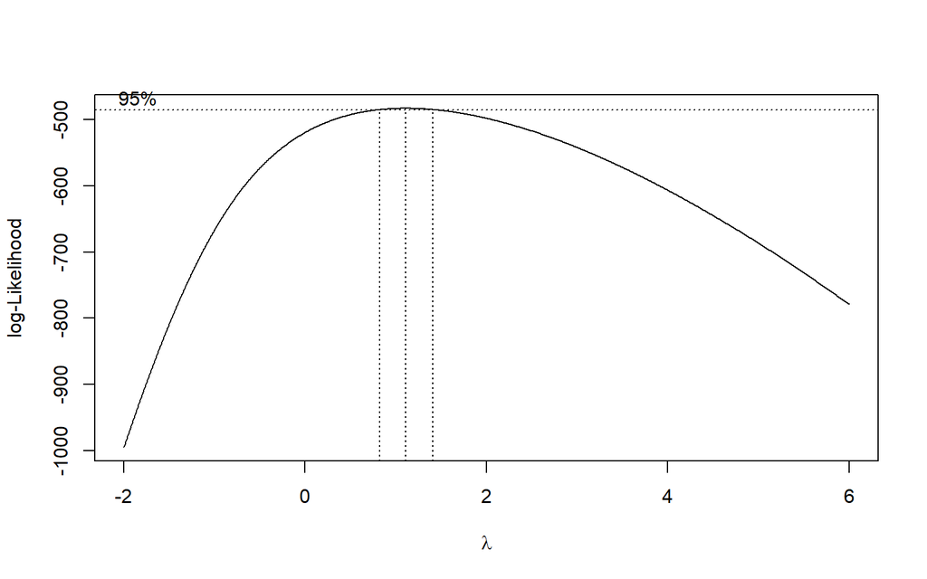

```r
arma_sim_pos <- arma_sim - min(arma_sim) + 1

index_arma_sim <- seq(1, 300)

bc_arma_sim <- boxcox(
  arma_sim_pos ~ index_arma_sim,
  lambda = seq(-2, 6, by = 0.01)
)
```

```r
# Nilai lambda optimum
lambda_arma_sim <- bc_arma_sim$x[
  which.max(bc_arma_sim$y)
]

lambda_arma_sim
```

```
## [1] 1.11
```

```r
ci_lambda_arma_sim <- bc_arma_sim$x[
  bc_arma_sim$y >
    max(bc_arma_sim$y) -
    0.5 * qchisq(0.95, 1)
]

ci_lower_arma_sim <- min(ci_lambda_arma_sim)
ci_upper_arma_sim <- max(ci_lambda_arma_sim)

c(
  Batas_Bawah = ci_lower_arma_sim,
  Batas_Atas = ci_upper_arma_sim
)
```

```
## Batas_Bawah  Batas_Atas
##        0.83        1.40
```

Hasil uji di atas menunjukkan nilai rounded value (λ) optimum sebesar 1.11 dan pada selang kepercayaan 95% nilai memiliki batas bawah 0.83 dan batas atas 1.40. Selang tersebut memuat nilai 1 sehingga dapat dikatakan bahwa data bangkitan stasioner dalam ragam

### Scatter Plot

#### $Y_t$ dengan $Y_{t-1}$

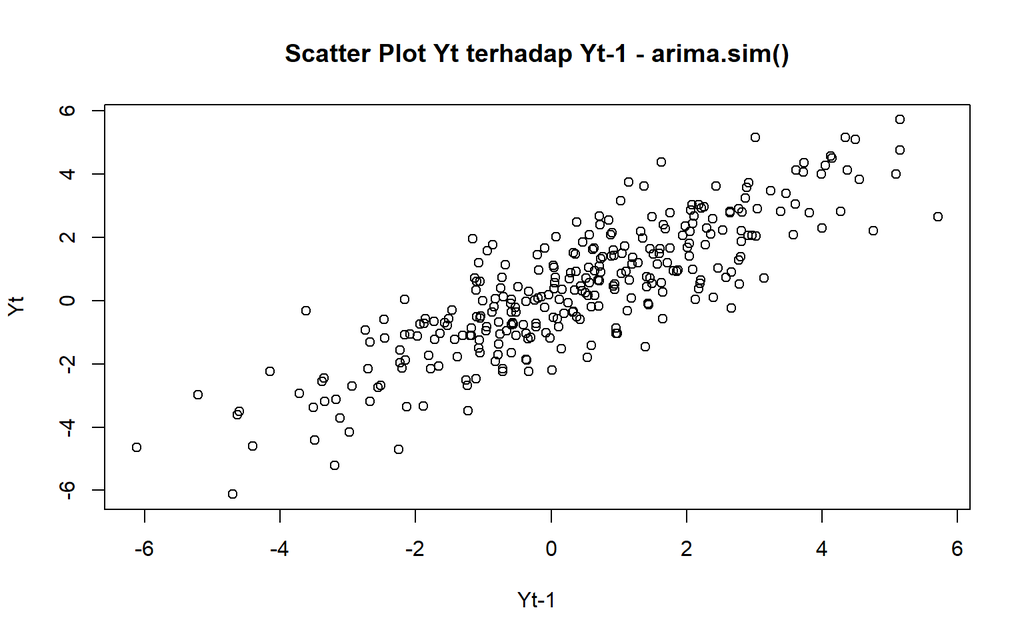

```r
yt_arma_sim <- arma_sim[2:300]
yt_1_arma_sim <- arma_sim[1:299]

plot(yt_1_arma_sim, yt_arma_sim,
     main = "Scatter Plot Yt terhadap Yt-1 - arima.sim()",
     xlab = "Yt-1",
     ylab = "Yt")
```

```r
cor(yt_arma_sim, yt_1_arma_sim)
```

```
## [1] 0.845632
```

Berdasarkan scatterplot dan nilai korelasi tersebut, terlihat bahwa terdapat hubungan positif antara Yt dengan Yt−1

#### $Y_t$ dengan $Y_{t-2}$

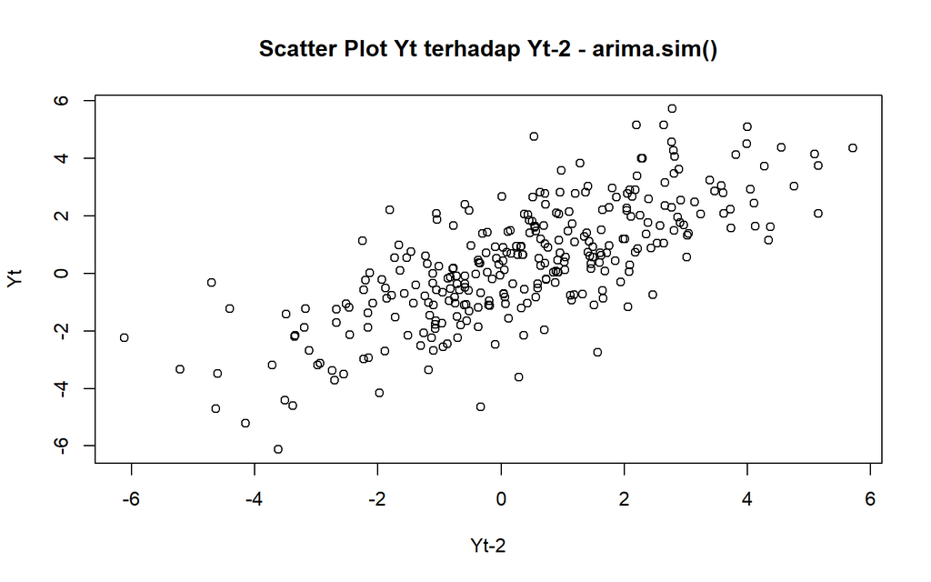

```r
yt_arma_sim_lag2 <- arma_sim[3:300]
yt_2_arma_sim <- arma_sim[1:298]

plot(yt_arma_sim_lag2, yt_2_arma_sim,
     main = "Scatter Plot Yt terhadap Yt-2 - arima.sim()",
     xlab = "Yt-2",
     ylab = "Yt")
```

```r
cor(yt_arma_sim_lag2, yt_2_arma_sim)
```

```
## [1] 0.7382661
```

Berdasarkan scatterplot dan nilai korelasi tersebut, terlihat bahwa terdapat hubungan positif antara Yt dengan Yt-2 dan lebih lemah dibandingkan hubungan dengan Yt-1

#### $Y_t$ dengan $Y_{t-3}$

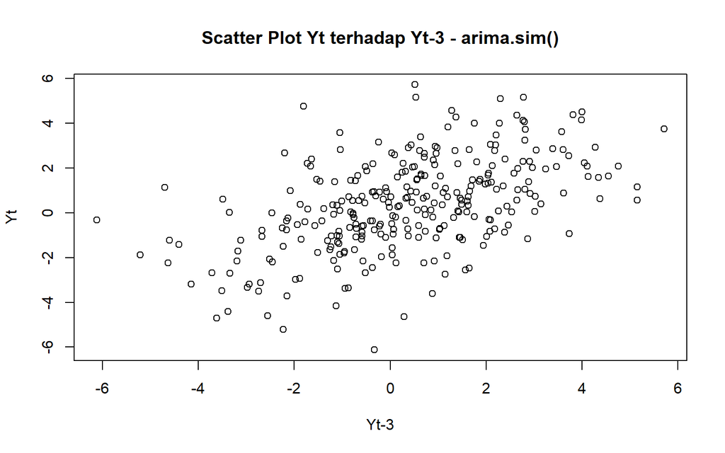

```r
yt_arma_sim_lag3 <- arma_sim[4:300]
yt_3_arma_sim <- arma_sim[1:297]

plot(yt_arma_sim_lag3, yt_3_arma_sim,
     main = "Scatter Plot Yt terhadap Yt-3 - arima.sim()",
     xlab = "Yt-3",
     ylab = "Yt")
```

```r
cor(yt_arma_sim_lag3, yt_3_arma_sim)
```

```
## [1] 0.5150221
```

Berdasarkan scatterplot dan nilai korelasi tersebut, terlihat bahwa terdapat hubungan positif antara Yt dengan Yt-3 dan lebih lemah dibandingkan hubungan dengan Yt-1 dan Yt-2

### Autokorelasi

#### Autokorelasi Data Bangkitan Manual

```r
rho1_arma_sim <- cor(arma_sim[2:300],arma_sim[1:299])

rho2_arma_sim <- cor(arma_sim[3:300],arma_sim[1:298])

rho3_arma_sim <- cor(arma_sim[4:300],arma_sim[1:297])

rho1_arma_sim
```

```
## [1] 0.845632
```

```r
rho2_arma_sim
```

```
## [1] 0.7382661
```

```r
rho3_arma_sim
```

```
## [1] 0.5150221
```

#### Autokorelasi Teoritis

```r
psi_arma_sim <- numeric(1000)

psi_arma_sim[1] <- 1

psi_arma_sim[2] <- 0.5 + 0.4

psi_arma_sim[3] <- 0.5 * psi_arma_sim[2] +
                   0.2 +
                   0.6

for(i in 4:1000){
  psi_arma_sim[i] <- 0.5 * psi_arma_sim[i-1] +
                     0.2 * psi_arma_sim[i-2]
}

gamma_arma_sim <- numeric(4)

for(k in 0:3){
  gamma_arma_sim[k+1] <-
    sum(
      psi_arma_sim[1:(1000-k)] *
      psi_arma_sim[(1+k):1000]
    )
}

rho_arma_teori_sim <- gamma_arma_sim / gamma_arma_sim[1]

rho_arma_teori_sim
```

```
## [1] 1.0000000 0.8591993 0.7491908 0.5464353
```

#### Perbandingan

```r
data.frame(
  Lag = 1:3,
  Simulasi = c(
    rho1_arma_sim,
    rho2_arma_sim,
    rho3_arma_sim
  ),
  Teoritis = c(
    rho_arma_teori_sim[2],
    rho_arma_teori_sim[3],
    rho_arma_teori_sim[4]
  ))
```

```
##   Lag  Simulasi  Teoritis
## 1   1 0.8456320 0.8591993
## 2   2 0.7382661 0.7491908
## 3   3 0.5150221 0.5464353
```

Autokorelasi pada proses ARMA(2,2) bernilai positif dan semakin menurun pada lag yang lebih tinggi. Hasil simulasi menunjukkan pola yang sejalan dengan nilai teoritis, meskipun terdapat perbedaan nilai akibat variasi sampel. Hal ini sesuai dengan karakteristik ARMA(2,2), di mana ACF menurun secara bertahap (tails off) dan tidak langsung terputus pada lag tertentu